# Project 6

Lakshmi Mounica Marupeddi

2024-07-18

```r
library(tidyverse)
library(nycflights13)
```

### Question 1

Create a new column in the flights set called “total_delay”. Select only the month, carrier, origin, dest, distance, total_delay, arr_delay columns. Save this to a new dataset called fl_new. You can use the code given below. Which of the following carriers has the smallest mean total delay in the fl_new data?

```r
fl_new = flights %>% mutate(total_delay = dep_delay+arr_delay) %>% select(month, carrier, origin, dest, distance,total_delay,  arr_delay)
fl_new %>% group_by(carrier) %>% summarize(smallestmean = mean(total_delay, na.rm = TRUE)) %>% arrange(smallestmean)
```

```
## # A tibble: 16 × 2
##    carrier smallestmean
##    <chr>          <dbl>
##  1 AS             -4.10
##  2 HA             -2.01
##  3 US              5.87
##  4 AA              8.93
##  5 DL             10.9
##  6 VX             14.5
##  7 UA             15.6
##  8 MQ             21.2
##  9 B6             22.4
## 10 9E             23.8
## 11 OO             24.5
## 12 WN             27.3
## 13 YV             34.5
## 14 EV             35.6
## 15 FL             38.7
## 16 F9             42.1
```

### Question 2

What are the key or common variables in the fl_new and airports datasets that you can use to join? A common variable means the values of the variables are the same, and as such can be used to join two datasets. The names of the variables may be different in the 2 sets. There can be more than one column that are common in both datasets. Hint: The common columns are the ones regarding the airport code. There are 3 right choices.

```r
fl_new
```

```
## # A tibble: 336,776 × 7
##    month carrier origin dest  distance total_delay arr_delay
##    <int> <chr>   <chr>  <chr>    <dbl>       <dbl>     <dbl>
##  1     1 UA      EWR    IAH       1400          13        11
##  2     1 UA      LGA    IAH       1416          24        20
##  3     1 AA      JFK    MIA       1089          35        33
##  4     1 B6      JFK    BQN       1576         -19       -18
##  5     1 DL      LGA    ATL        762         -31       -25
##  6     1 UA      EWR    ORD        719           8        12
##  7     1 B6      EWR    FLL       1065          14        19
##  8     1 EV      LGA    IAD        229         -17       -14
##  9     1 B6      JFK    MCO        944         -11        -8
## 10     1 AA      LGA    ORD        733           6         8
## # ℹ 336,766 more rows
```

### Question 3

Join the “fl_new” and the “airports” data using the code given below and save it to “fl_airport”. If done correctly the first few rows should look like the table given in the image. From now on use “fl_airport” data to answer the questions. How many flights are there to “Tampa Intl” airport in June?

```r
fl_airport = inner_join(fl_new, airports, by = c('dest'= 'faa'))
head(fl_airport)
```

```
## # A tibble: 6 × 14
##   month carrier origin dest  distance total_delay arr_delay name       lat   lon
##   <int> <chr>   <chr>  <chr>    <dbl>       <dbl>     <dbl> <chr>    <dbl> <dbl>
## 1     1 UA      EWR    IAH       1400          13        11 George …  30.0 -95.3
## 2     1 UA      LGA    IAH       1416          24        20 George …  30.0 -95.3
## 3     1 AA      JFK    MIA       1089          35        33 Miami I…  25.8 -80.3
## 4     1 DL      LGA    ATL        762         -31       -25 Hartsfi…  33.6 -84.4
## 5     1 UA      EWR    ORD        719           8        12 Chicago…  42.0 -87.9
## 6     1 B6      EWR    FLL       1065          14        19 Fort La…  26.1 -80.2
## # ℹ 4 more variables: alt <dbl>, tz <dbl>, dst <chr>, tzone <chr>
```

```r
fl_airport %>% filter(month==6 & name == "Tampa Intl") %>% count()
```

```
## # A tibble: 1 × 1
##       n
##   <int>
## 1   603
```

### Question 4

Which month experienced the largest average total_delay in the fl_airport data?

```r
fl_airport %>% group_by(month) %>% summarize(means = mean(total_delay, na.rm = TRUE))  %>% arrange(-means)
```

```
## # A tibble: 12 × 2
##    month means
##    <int> <dbl>
##  1     7 38.3
##  2     6 37.6
##  3    12 31.6
##  4     4 25.4
##  5     3 19.2
##  6     8 18.4
##  7     5 16.7
##  8     2 16.6
##  9     1 16.5
## 10    10  6.27
## 11    11  6.07
## 12     9  2.66
```

### Question 5

Continue working on fl_airport data. What is the average arr_delay in flights to “Tampa Intl” airport in September?

```r
fl_airport %>% filter(month==9 & name == "Tampa Intl") %>% summarize(mean(arr_delay, na.rm=TRUE))
```

```
## # A tibble: 1 × 1
##   `mean(arr_delay, na.rm = TRUE)`
##                             <dbl>
## 1                           -8.81
```

### Question 6

Continue working on fl_airport data. What is the mean “distance” in flights to “Chicago Ohare Intl” airport in July? Choose the closest value.

```r
fl_airport %>% filter(month==7 & name == "Chicago Ohare Intl") %>% summarize(mean(distance, na.rm=TRUE))
```

```
## # A tibble: 1 × 1
##   `mean(distance, na.rm = TRUE)`
##                            <dbl>
## 1                           729.
```

### Question 7

Continue working on fl_airport data. Which one of the following is the airport with largest average arr_delay?

```r
fl_airport %>% group_by(name) %>% summarize(means = mean(arr_delay, na.rm = TRUE)) %>% arrange(-means)
```

```
## # A tibble: 101 × 2
##    name                          means
##    <chr>                         <dbl>
##  1 Columbia Metropolitan          41.8
##  2 Tulsa Intl                     33.7
##  3 Will Rogers World              30.6
##  4 Jackson Hole Airport           28.1
##  5 Mc Ghee Tyson                  24.1
##  6 Dane Co Rgnl Truax Fld         20.2
##  7 Richmond Intl                  20.1
##  8 Akron Canton Regional Airport  19.7
##  9 Des Moines Intl                19.0
## 10 Gerald R Ford Intl             18.2
## # ℹ 91 more rows
```

### Question 8

Continue working on fl_airport data. Which one of the following is the airport that has the largest average arr_delay that had at least 10,000 arrivals? Hint: First get the airports with at least 10,000 arrivals. Then check the mean arrival delay among those airports.

```r
temp = fl_airport %>% group_by(name) %>% summarize(n=n()) %>% filter(n >= 10000)
t = inner_join(fl_airport, temp, by = c("name" = "name"))
t %>% group_by(name) %>% summarize(means = mean(arr_delay, na.rm = TRUE)) %>% arrange(-means)
```

```
## # A tibble: 9 × 2
##   name                                means
##   <chr>                               <dbl>
## 1 Hartsfield Jackson Atlanta Intl    11.3
## 2 Fort Lauderdale Hollywood Intl      8.08
## 3 Charlotte Douglas Intl              7.36
## 4 Chicago Ohare Intl                  5.88
## 5 Orlando Intl                        5.45
## 6 General Edward Lawrence Logan Intl  2.91
## 7 San Francisco Intl                  2.67
## 8 Los Angeles Intl                    0.547
## 9 Miami Intl                          0.299
```

### Question 9

Continue using fl_airport data. Plot a histogram of the distance variable with default settings. Approximately what is the most common distance flown?

```r
fl_airport %>% summarize(mean(distance, na.rm = TRUE))
```

```
## # A tibble: 1 × 1
##   `mean(distance, na.rm = TRUE)`
##                            <dbl>
## 1                          1027.
```

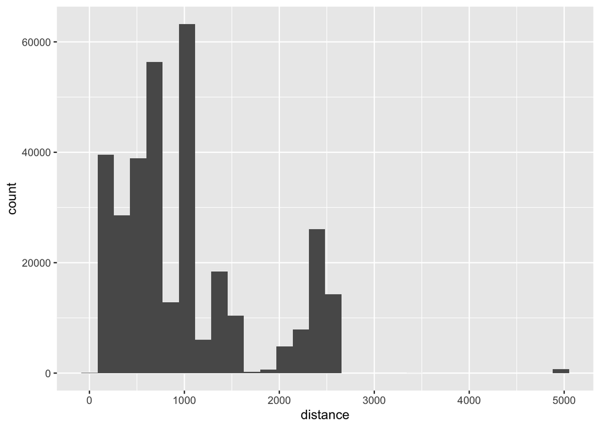

```r
fl_airport %>% ggplot(aes(x=distance)) + geom_histogram()
```

### Question 10

Continue using fl_airport data. Plot a scatter chart using ggplot of arrival delay vs distance. The plotting will take some time and should look like the following. What can we conclude from the plot? If you try to plot using all the data points, it will be very slow - so you should first sample points from the data. The plot is given below. (3 correct choices)

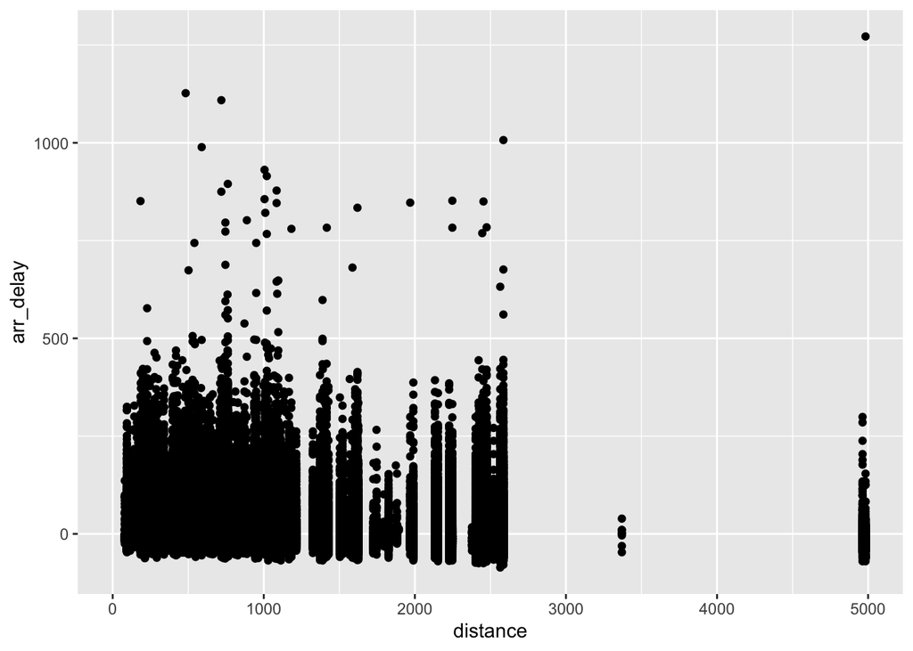

```r
fl_airport %>% ggplot(aes(x=distance, y=arr_delay)) + geom_point()
```

### Question 11

Continue using fl_airport data. Filter the carrier UA and create a histogram using 100 bins. What can we say based on the histogram?

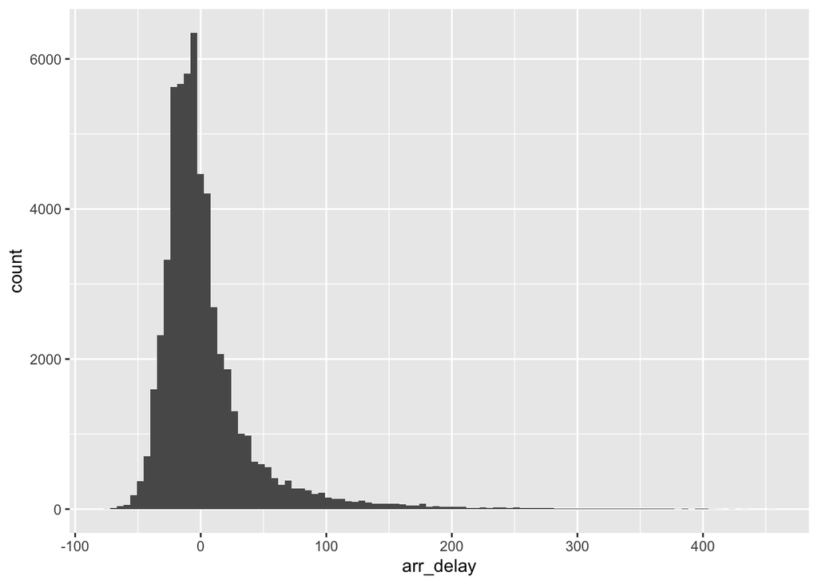

```r
fl_airport %>% filter(carrier=="UA") %>% ggplot(aes(x=arr_delay)) + geom_histogram(bins = 100)
```

### Question 12

Now go back to flights dataset. Create a scatter plot of dep_delay vs arr_delay using carrier UA’s data only. Which of the following statements are correct? (More than one are possible)

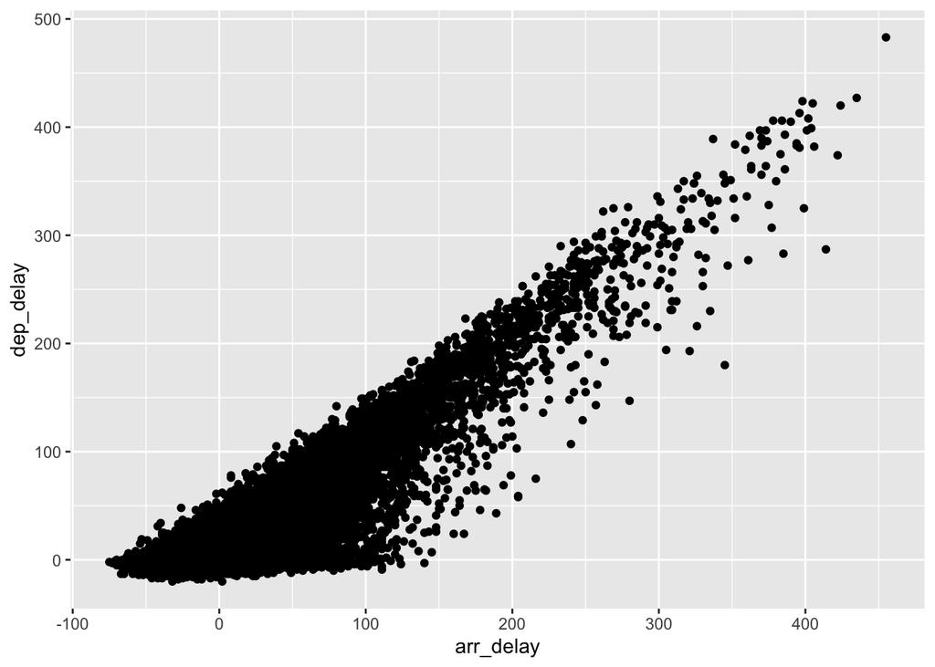

```r
tempj = flights %>% filter(carrier=="UA")
tempj %>% ggplot(aes(x=arr_delay, y=dep_delay)) + geom_point()
```

```r
cor(tempj$arr_time, tempj$dep_delay, use = "complete.obs")
```

```
## [1] 0.02908659
```